# Projekt

Marcin Mika, Filip Kopańko

2025-01-14

# Wstęp

Celem tej pracy jest przeprowadzenie analizy, zrozumienie oraz przewidywanie występowania depresji wśród studentów na podstawie różnych czynników społecznych, edukacyjnych oraz zdrowotnych. Projekt opiera się na eksploracyjnej analizie dostarczonych danych, obejmujących m.in. poziom presji akademickiej, nawyki żywieniowe, długość snu oraz historię zdrowotną. Dodatkowo celem jest opracowanie modeli predykcyjnych wykorzystujących różne metody uczenia maszynowego (w tym SVM i drzewa decyzyjne) oraz analiza interpretowalności wyników w celu identyfikacji kluczowych zmiennych wpływających na ryzyko depresji.

# EDA i przygotowanie danych

Dane obejmują 18 kolumn i 27,901 wierszy. Główne zmienne to:

- **Gender**: Płeć uczestnika (np. Male, Female).
- **Age**: Wiek uczestnika.
- **City**: Miejsce zamieszkania.
- **Profession**: Zawód (np. Student).
- **Academic Pressure**: Poziom presji akademickiej (skala 0-5).
- **Work Pressure**: Poziom presji zawodowej (skala 0-5).
- **CGPA**: Średnia ocen.
- **Study Satisfaction**: Satysfakcja z nauki (skala 0-5).
- **Job Satisfaction**: Satysfakcja z pracy (skala 0-4).
- **Sleep Duration**: Czas trwania snu (np. “5-6 hours”).
- **Dietary Habits**: Nawyki żywieniowe (Healthy, Moderate, Unhealthy).
- **Degree**: Typ ukończonych studiów.
- **Have you ever had suicidal thoughts?**: Czy uczestnik miał myśli samobójcze? (Yes/No).
- **Work/Study Hours**: Godziny pracy/nauki dziennie.
- **Financial Stress**: Poziom stresu finansowego (skala 1-5).
- **Family History of Mental Illness**: Historia chorób psychicznych w rodzinie (Yes/No).
- **Depression**: Czy uczestnik cierpi na depresję? (1: Tak, 0: Nie).

```r
data <- read.csv("Student Depression Dataset.csv")
data
```

| id | Gender | Age | City | Profession | Academic.Pressure | Work.Pressure | CGPA | Study.Satisfaction | Job.Satisfaction | Sleep.Duration | Dietary.Habits | Degree | Have.you.ever.had.suicidal.thoughts.. | Work.Study.Hours | Financial.Stress | Family.History.of.Mental.Illness | Depression |
| --- | --- | --- | --- | --- | --- | --- | --- | --- | --- | --- | --- | --- | --- | --- | --- | --- | --- |
| 2 | Male | 33 | Visakhapatnam | Student | 5 | 0 | 8.97 | 2 | 0 | 5-6 hours | Healthy | B.Pharm | Yes | 3 | 1 | No | 1 |
| 8 | Female | 24 | Bangalore | Student | 2 | 0 | 5.90 | 5 | 0 | 5-6 hours | Moderate | BSc | No | 3 | 2 | Yes | 0 |
| 26 | Male | 31 | Srinagar | Student | 3 | 0 | 7.03 | 5 | 0 | Less than 5 hours | Healthy | BA | No | 9 | 1 | Yes | 0 |
| 30 | Female | 28 | Varanasi | Student | 3 | 0 | 5.59 | 2 | 0 | 7-8 hours | Moderate | BCA | Yes | 4 | 5 | Yes | 1 |
| 32 | Female | 25 | Jaipur | Student | 4 | 0 | 8.13 | 3 | 0 | 5-6 hours | Moderate | M.Tech | Yes | 1 | 1 | No | 0 |
| 33 | Male | 29 | Pune | Student | 2 | 0 | 5.70 | 3 | 0 | Less than 5 hours | Healthy | PhD | No | 4 | 1 | No | 0 |
| 52 | Male | 30 | Thane | Student | 3 | 0 | 9.54 | 4 | 0 | 7-8 hours | Healthy | BSc | No | 1 | 2 | No | 0 |
| 56 | Female | 30 | Chennai | Student | 2 | 0 | 8.04 | 4 | 0 | Less than 5 hours | Unhealthy | Class 12 | No | 0 | 1 | Yes | 0 |
| 59 | Male | 28 | Nagpur | Student | 3 | 0 | 9.79 | 1 | 0 | 7-8 hours | Moderate | B.Ed | Yes | 12 | 3 | No | 1 |
| 62 | Male | 31 | Nashik | Student | 2 | 0 | 8.38 | 3 | 0 | Less than 5 hours | Moderate | LLB | Yes | 2 | 5 | No | 1 |

[output cut: 9990 more lines]

Do badania bierzemy tylko niepracujących studentów, więc usuwamy wszystkie niespełniające tego warunku obserwacje i usuwamy niepotrzebne kolumny: ‘**Job Satisfaction’**,’**Work Pressure**’ oraz ‘**Profession**’. Dodatkowo usuwamy zmienną ‘**City**’, ponieważ zawierała bardzo dużą liczbę unikalnych wartości, co sprawiało, że trudno było ją skutecznie skategoryzować w sposób, który wniósłby istotną wartość do analizy.

```r
library(dplyr)
data <- read.csv("Student Depression Dataset.csv")
data <- data[data$Profession == "Student" & data$Work.Pressure == 0, ]
data <- data[, !colnames(data) %in% c("Profession", "Work.Pressure", "Job.Satisfaction", "City")]
```

Wartości zmiennej ‘**Degree**’ podobnie jak zmiennej ‘**City**’ były trudne do skategoryzowania, zdecydowaliśmy się więc na pogrupowanie ich w bardziej ogólne kategorie w zależności od poziomu wykształcenia i dziedziny nauki (Zmienna ’**Degree’** została usunięta).

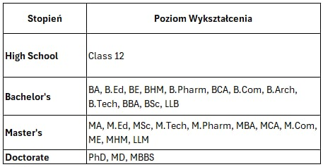

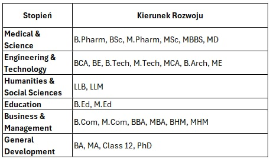

Zmienne kategoryczne: Gender, Sleep.Duration, Dietary.Habits, Have.you.ever.had.suicidal.thoughts.., Family.History.of.Mental.Illness, Degree_Level, Career_Path

Zmienne liczbowe: Age, Academic.Pressure, CGPA, Study.Satisfaction, Work.Study.Hours, Financial.Stress

```r
library(dplyr)
data <- data %>% filter(Degree != "Others")
data <- data %>%
  # Tworzenie kolumny Degree_Level
  mutate(Degree_Level = case_when(
    Degree == "Class 12" ~ "High School",
    Degree %in% c("BA", "B.Ed", "BE", "BHM", "B.Pharm", "BCA", "B.Com", "B.Arch", "B.Tech", "BBA", "BSc", "LLB") ~ "Bachelor's",
    Degree %in% c("MA", "M.Ed", "MSc", "M.Tech", "M.Pharm", "MBA", "MCA", "M.Com", "ME", "MHM", "LLM") ~ "Master's",
    Degree %in% c("PhD", "MD", "MBBS") ~ "Doctorate",
    TRUE ~ "Others"
  ))

data <- data %>%
  mutate(Career_Path = case_when(
    Degree %in% c("B.Pharm", "BSc", "M.Pharm", "MSc", "MBBS", "MD") ~ "Medical & Science",
    Degree %in% c("BCA", "BE", "B.Tech", "M.Tech", "MCA", "B.Arch", "ME") ~ "Engineering & Technology",
    Degree %in% c("LLB", "LLM") ~ "Humanities & Social Sciences",
    Degree %in% c("B.Ed", "M.Ed") ~ "Education",
    Degree %in% c("B.Com", "M.Com", "BBA", "MBA", "BHM", "MHM") ~ "Business & Management",
    Degree %in% c("BA","MA","Class 12", "PhD") ~ "General Development",
    TRUE ~ NA_character_  # Dla bezpieczeństwa
  ))

data <- data %>% select(-Degree)
```

```r
library(knitr)
data_model <- data
data_model <- data_model %>%
  filter(Sleep.Duration != "Others",
         Dietary.Habits != "Others",
         CGPA != 0,
         !is.na(Financial.Stress))

data_model$id <- NULL

data_model$Gender <- as.factor(data_model$Gender)
data_model$Sleep.Duration <- as.factor(data_model$Sleep.Duration)

data_model$Sleep.Duration <- as.factor(ifelse(data_model$Sleep.Duration == "Less than 5 hours", 1,
                             ifelse(data_model$Sleep.Duration == "5-6 hours", 2,
                             ifelse(data_model$Sleep.Duration == "7-8 hours", 3,
                             ifelse(data_model$Sleep.Duration == "More than 8 hours", 4, NA)))))

data_model$Dietary.Habits <- as.factor(ifelse(data_model$Dietary.Habits == "Healthy", 1,
                             ifelse(data_model$Dietary.Habits == "Moderate", 2,
                             ifelse(data_model$Dietary.Habits == "Unhealthy", 3,
                             ifelse(data_model$Dietary.Habits == "Others", 4, NA)))))

data_model$Degree_Level <- as.factor(ifelse(data_model$Degree_Level == "High School", 0,
                           ifelse(data_model$Degree_Level == "Bachelor's", 1,
                           ifelse(data_model$Degree_Level == "Master's", 2,
                           ifelse(data_model$Degree_Level == "Doctorate", 3, 4)))))

# Zamiana wartości w kolumnie Career_Path na numeryczne
data_model$Career_Path <- as.factor(ifelse(data_model$Career_Path == "Medical & Science", 0,
                          ifelse(data_model$Career_Path == "Engineering & Technology", 1,
                          ifelse(data_model$Career_Path == "Humanities & Social Sciences", 2,
                          ifelse(data_model$Career_Path == "Education", 3,
                          ifelse(data_model$Career_Path == "Business & Management", 4,
                          ifelse(data_model$Career_Path == "General Development", 5, NA)))))))




data_model$Have.you.ever.had.suicidal.thoughts.. <- as.factor(data_model$Have.you.ever.had.suicidal.thoughts..)

data_model$Family.History.of.Mental.Illness <- as.factor(data_model$Family.History.of.Mental.Illness)

data_model$Depression <- as.factor(data_model$Depression)
data_model$Study.Satisfaction <- as.factor(data_model$Study.Satisfaction)
data_model$Academic.Pressure <- as.factor(data_model$Academic.Pressure)
data_model$Financial.Stress <- as.factor(data_model$Financial.Stress)
data_model$Degree_Level <- as.factor(data_model$Degree_Level)
data_model$Career_Path <- as.factor(data_model$Career_Path)

structure_table <- data.frame(
  Variable = names(data_model),
  Class = sapply(data_model, class),
  Rows = sapply(data_model, function(x) length(unique(x)))
)

# Wyświetlenie tabeli
kable(structure_table, caption = "Struktura danych w model_data")
```

Struktura danych w model_data

|  | Variable | Class | Rows |
| --- | --- | --- | --- |
| Gender | Gender | factor | 2 |
| Age | Age | numeric | 34 |
| Academic.Pressure | Academic.Pressure | factor | 6 |
| CGPA | CGPA | numeric | 331 |
| Study.Satisfaction | Study.Satisfaction | factor | 6 |
| Sleep.Duration | Sleep.Duration | factor | 4 |
| Dietary.Habits | Dietary.Habits | factor | 3 |
| Have.you.ever.had.suicidal.thoughts.. | Have.you.ever.had.suicidal.thoughts.. | factor | 2 |
| Work.Study.Hours | Work.Study.Hours | numeric | 13 |
| Financial.Stress | Financial.Stress | factor | 5 |
| Family.History.of.Mental.Illness | Family.History.of.Mental.Illness | factor | 2 |
| Depression | Depression | factor | 2 |
| Degree_Level | Degree_Level | factor | 4 |
| Career_Path | Career_Path | factor | 6 |

Usunęliśmy wiersze z brakującymi wartościami (NA) oraz wartościami “Others” w wybranych zmiennych. Ponieważ braków danych było niewiele, zdecydowaliśmy się je usunąć, zamiast stosować imputację.

Zamieniliśmy wartości tekstowe w zmiennych takich jak Gender, Sleep.Duration, Dietary.Habits, Degree_Level i Career_Path na wartości numeryczne, aby ułatwić ich analizę ilościową.

Dostosowaliśmy dane, aby były gotowe do dalszej analizy statystycznej i budowy modeli predykcyjnych. Wszystkie zmienne są teraz w formie liczbowej lub binarnej.

Summary Table for Numeric Variables

|  | Age | CGPA | Work.Study.Hours |
| --- | --- | --- | --- |
|  | Min. :18.00 | Min. : 5.030 | Min. : 0.00 |
|  | 1st Qu.:21.00 | 1st Qu.: 6.290 | 1st Qu.: 4.00 |
|  | Median :25.00 | Median : 7.770 | Median : 8.00 |
|  | Mean :25.82 | Mean : 7.659 | Mean : 7.16 |
|  | 3rd Qu.:30.00 | 3rd Qu.: 8.920 | 3rd Qu.:10.00 |
|  | Max. :59.00 | Max. :10.000 | Max. :12.00 |

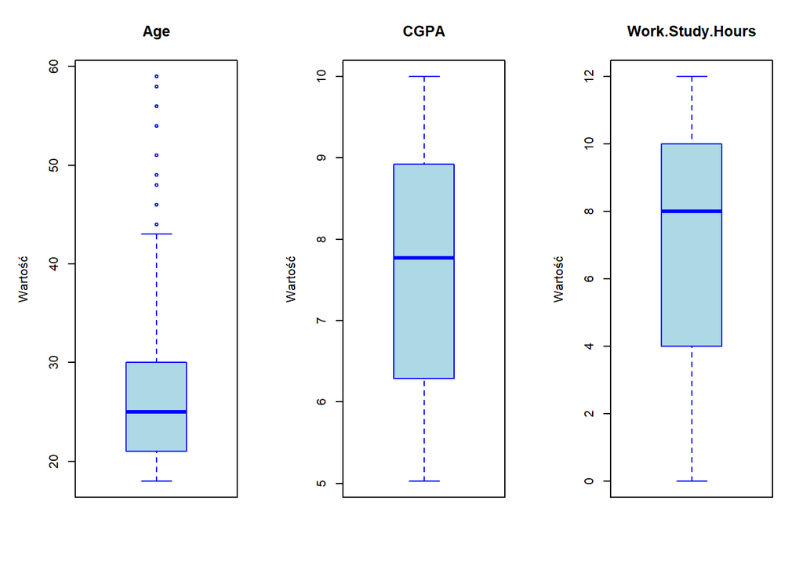

```r
numeric_vars <- names(data_model)[sapply(data_model, function(x) is.numeric(x) && length(unique(x)) > 2)]


par(mfrow = c(1,3), mar = c(5, 5, 4, 2)) # Układ 2x5, większe marginesy

# Tworzenie wykresów pudełkowych
for (var in numeric_vars) {
  boxplot(data_model[[var]],
          main = paste(var),
          ylab = "Wartość",
          col = "lightblue",
          border = "blue",
          outline = TRUE) # Rysowanie wartości odstających
}
```

```r
# Resetowanie układu
par(mfrow = c(1, 1))
```

Zmienna Age zawiera wartości odstające, które wykraczają poza typowy zakres zmienności, wskazując na obecność niewielkiej liczby obserwacji reprezentujących starsze osoby w analizowanej populacji. Wartości odstające w zmiennej Age zastępujemy wartościami odpowiadającymi granicom wąsów wykresu pudełkowego, co pozwala na ograniczenie ich wpływu na analizę przy jednoczesnym zachowaniu integralności danych.

```r
q1 <- quantile(data_model$Age, 0.25, na.rm = TRUE) # Pierwszy kwartyl
q3 <- quantile(data_model$Age, 0.75, na.rm = TRUE) # Trzeci kwartyl
iqr <- q3 - q1                                     # Rozstęp międzykwartylowy

lower_bound <- q1 - 1.5 * iqr                      # Dolna granica
upper_bound <- q3 + 1.5 * iqr                      # Górna granica

# Zastępowanie wartości odstających granicami IQR
data_model$Age <- ifelse(data_model$Age < lower_bound, lower_bound,
                         ifelse(data_model$Age > upper_bound, upper_bound,
                                data_model$Age))
```

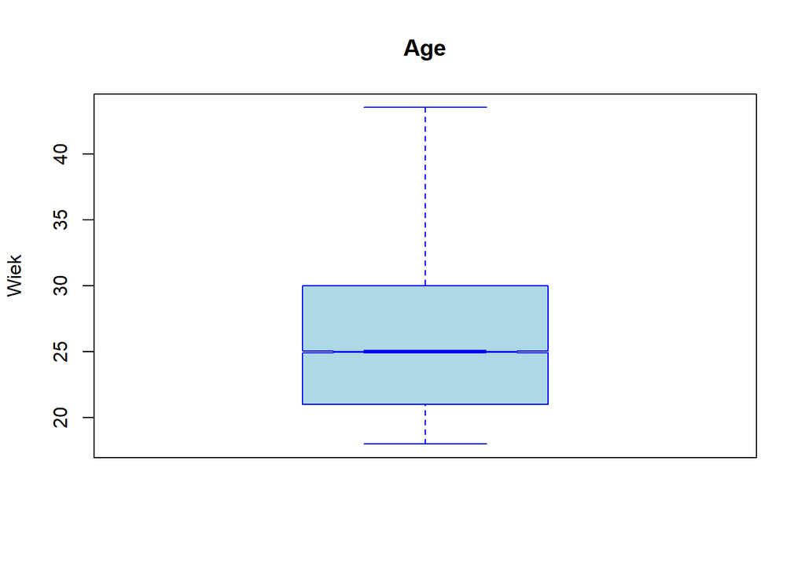

```r
boxplot(data_model$Age,
        main = "Age",
        ylab = "Wiek",
        col = "lightblue",
        border = "blue",
        outline = TRUE, # Pokaż wartości odstające
        notch = TRUE)
```

Wykresy częstości:

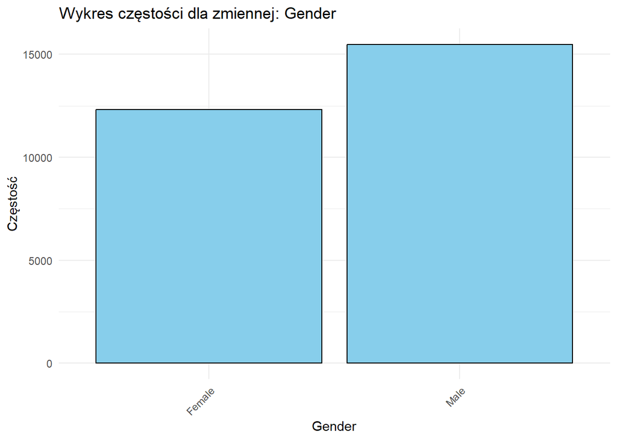

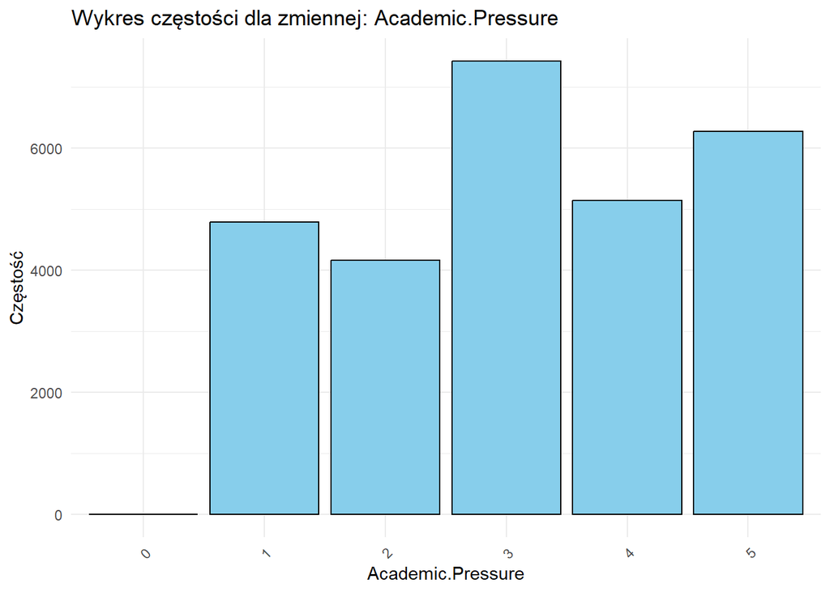

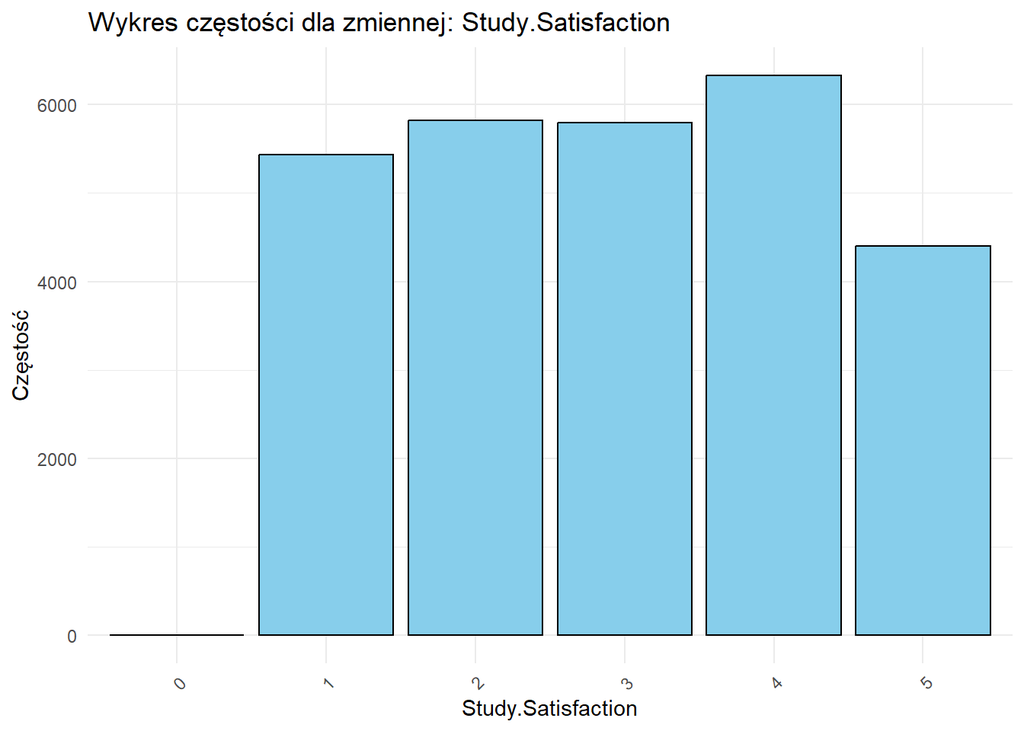

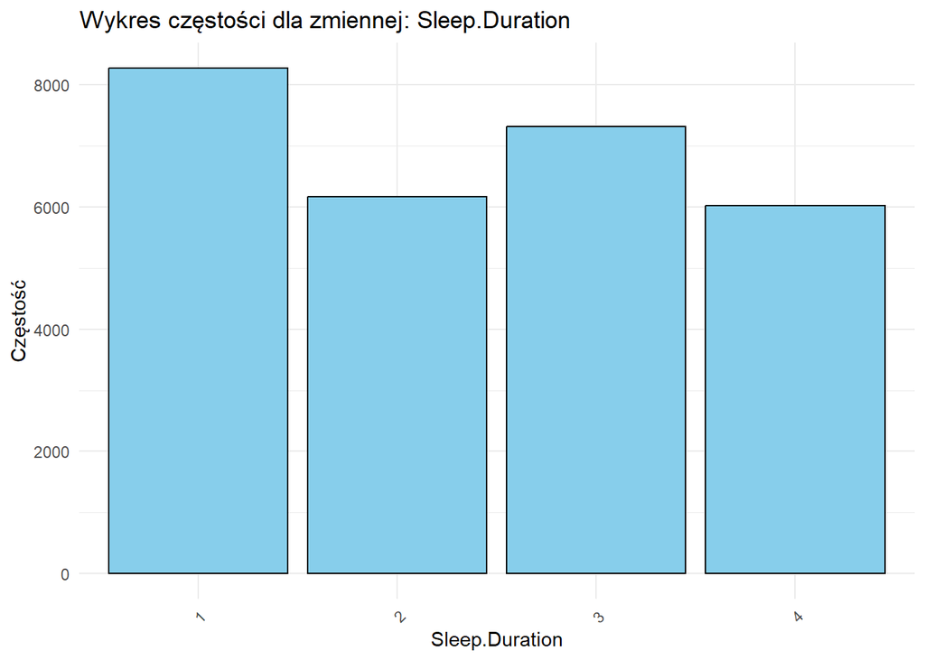

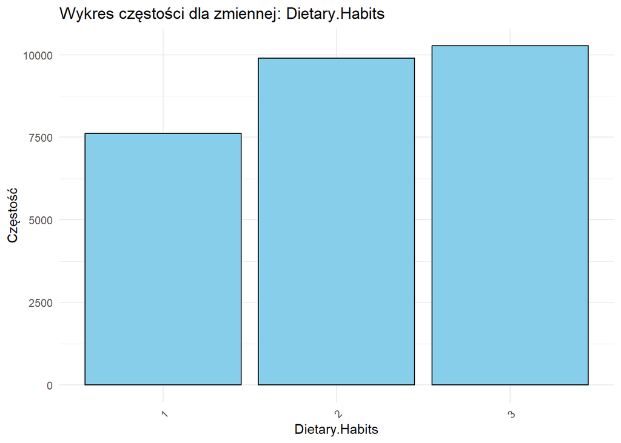

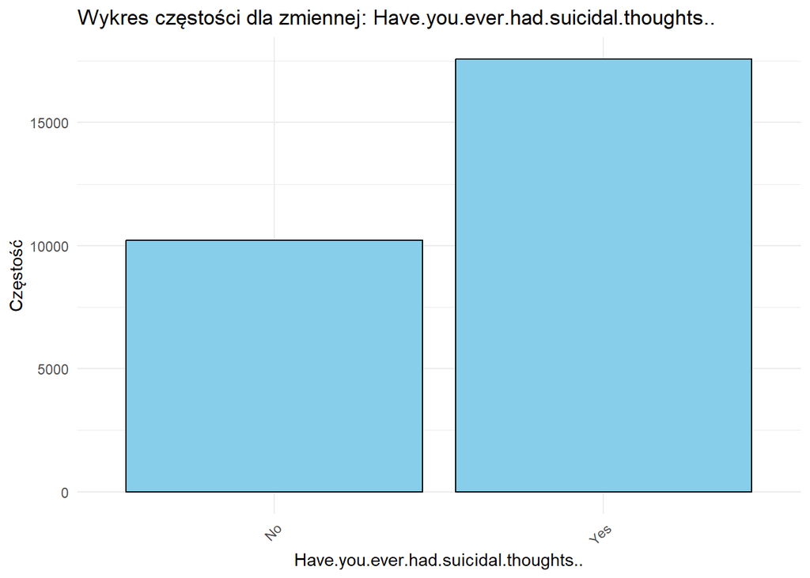

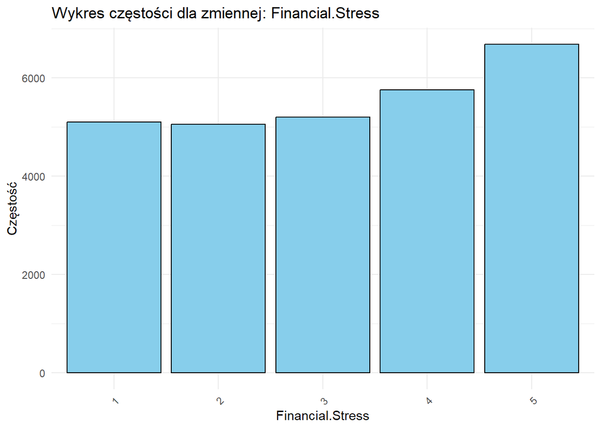

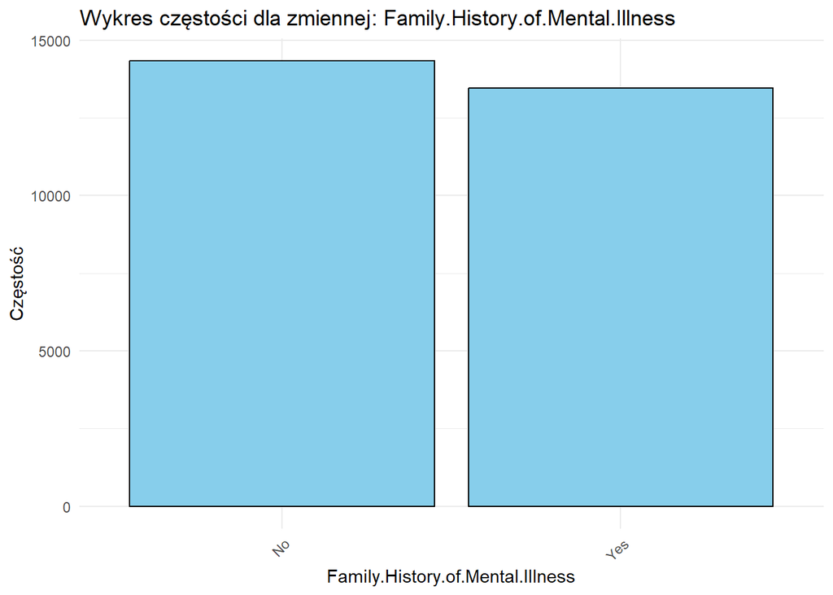

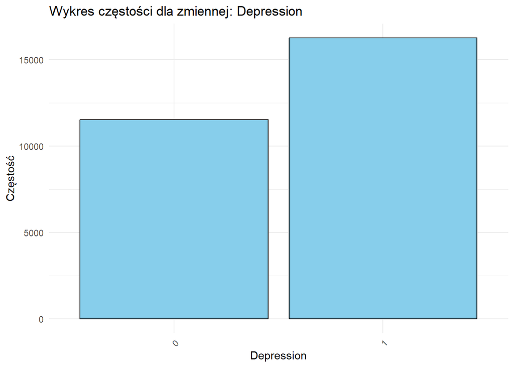

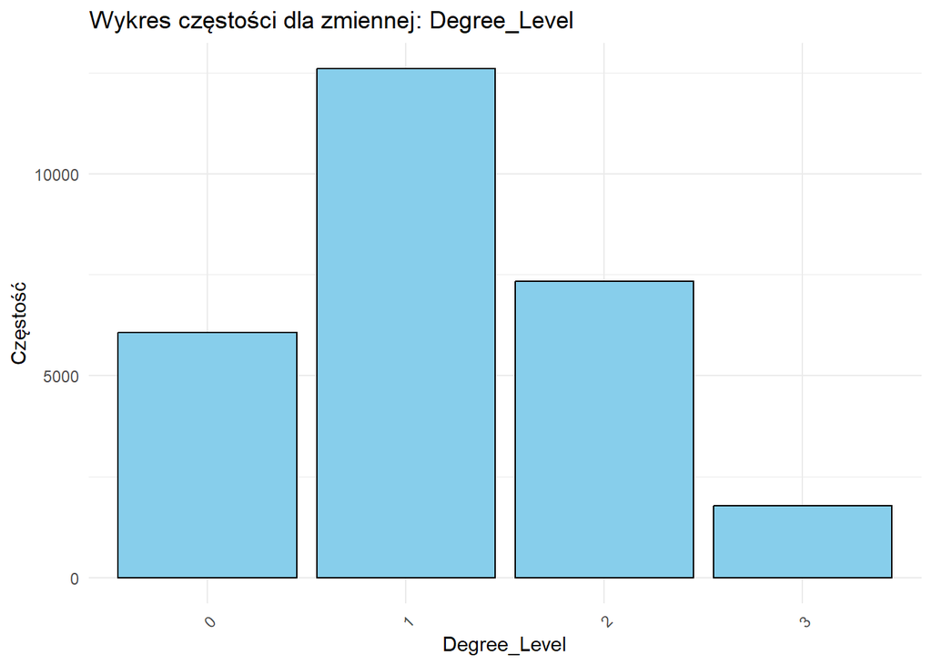

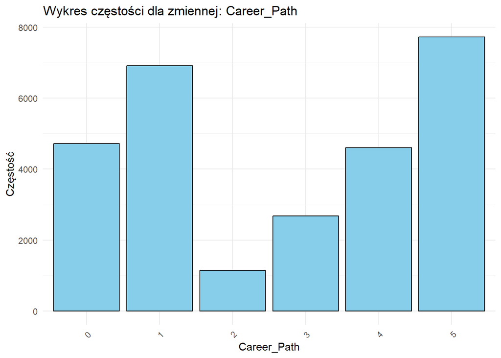

```r
library(ggplot2)
categorical_vars <- data_model[, sapply(data_model, is.factor)]

# Pętla do tworzenia wykresów dla każdej zmiennej faktorowej
for (var_name in names(categorical_vars)) {
  # Wykres dla zmiennej
  p <- ggplot(data_model, aes_string(x = var_name)) +
    geom_bar(fill = "skyblue", color = "black") +
    ggtitle(paste("Wykres częstości dla zmiennej:", var_name)) +
    xlab(var_name) +
    ylab("Częstość") +
    theme_minimal() +
    theme(axis.text.x = element_text(angle = 45, hjust = 1)) # Obrót etykiet na osi X

  # Wyświetlenie wykresu
  print(p)
}
```

Szczególną uwagę zwróciły wykresy zmiennych Academic.Pressure oraz Study.Satisfaction, gdzie wartości 0 są zdecydowanie wartościami odstającymi. Postanowiliśmy usunąć te rekordy.

```r
data_model <- data_model[!(data_model$Study.Satisfaction == 0 | data_model$Academic.Pressure == 0), ]
```

Macierz korelacji zminnej objaśnianej (przedstawionej jako numeryczna) z zmiennymi numerycznymi:

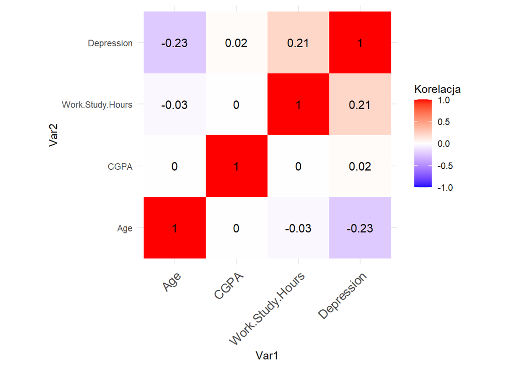

```r
library(ggplot2)
library(reshape2)

# Przykładowe dane
# data_model <- read.csv("path_to_your_data.csv")

# Przekształć zmienną Depression na zmienną numeryczną
data_model$Depression <- as.numeric(as.character(data_model$Depression))

# Wybierz tylko zmienne numeryczne
numeric_vars <- sapply(data_model, is.numeric)
data_numeric <- data_model[, numeric_vars]

# Oblicz macierz korelacji
cor_matrix <- cor(data_numeric, use = "complete.obs")

# Przekształć macierz korelacji do formatu długiego
melted_cor_matrix <- melt(cor_matrix)

# Narysuj macierz korelacji z wartościami
ggplot(data = melted_cor_matrix, aes(x = Var1, y = Var2, fill = value)) +
  geom_tile() +
  geom_text(aes(label = round(value, 2)), color = "black", size = 4) +
  scale_fill_gradient2(low = "blue", high = "red", mid = "white",
                       midpoint = 0, limit = c(-1, 1), space = "Lab",
                       name="Korelacja") +
  theme_minimal() +
  theme(axis.text.x = element_text(angle = 45, vjust = 1,
                                   size = 12, hjust = 1)) +
  coord_fixed()
```

```r
data_model$Depression <- as.factor(data_model$Depression)
```

W macierzy korelacji nie występują wysokie wartości (|r| ≥ 0.7). Zmienne objaśniające nie są ze sobą skorelowane, co jest dobrym sygnałem. Z drugiej strony może martwić ich niska korelacja ze zmienną objaśnianą.

Macierz V-Cramer zmiennych kategorycznych:

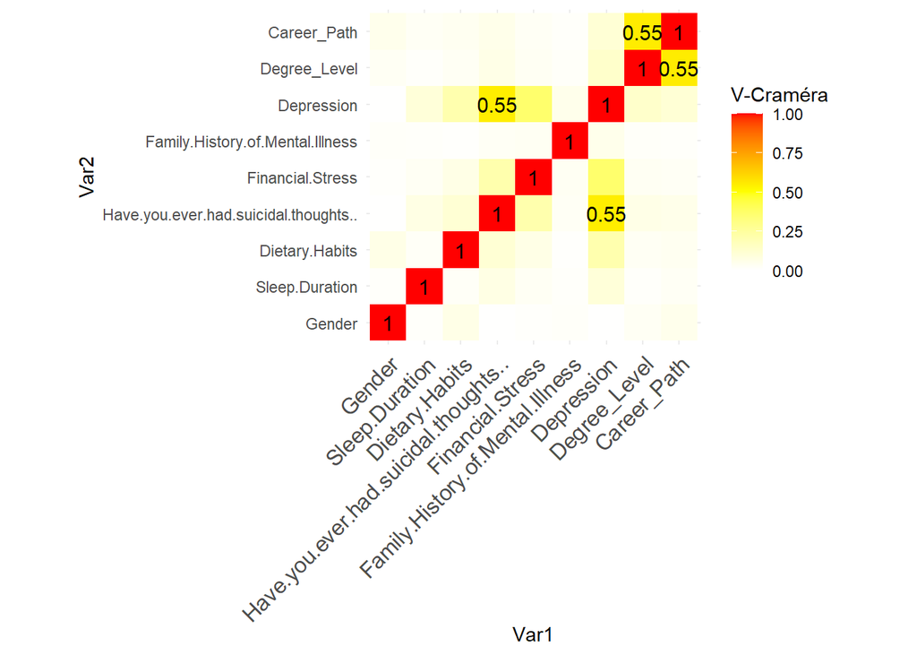

```r
library(vcd)
library(reshape2)
library(ggplot2)

# Przykładowe dane
# data_model <- read.csv("path_to_your_data.csv")

# Wybierz tylko zmienne kategoryczne
categorical_vars <- sapply(data_model, is.factor)
data_categorical <- data_model[, categorical_vars]

# Funkcja do obliczania V-Craméra
cramers_v <- function(x, y) {
  tbl <- table(x, y)
  chi2 <- chisq.test(tbl)$statistic
  n <- sum(tbl)
  min_dim <- min(dim(tbl)) - 1
  v <- sqrt(chi2 / (n * min_dim))
  return(v)
}

# Oblicz macierz V-Craméra
var_names <- colnames(data_categorical)
n <- length(var_names)
cramer_matrix <- matrix(NA, n, n, dimnames = list(var_names, var_names))

for (i in 1:n) {
  for (j in 1:n) {
    cramer_matrix[i, j] <- cramers_v(data_categorical[, i], data_categorical[, j])
  }
}

# Przekształć macierz do formatu długiego
melted_cramer_matrix <- melt(cramer_matrix, na.rm = TRUE)

# Narysuj macierz V-Craméra z wartościami większymi od 0.5
ggplot(data = melted_cramer_matrix, aes(x = Var1, y = Var2, fill = value)) +
  geom_tile() +
  geom_text(data = subset(melted_cramer_matrix, value > 0.5),
            aes(label = round(value, 2)), color = "black", size = 4) +
  scale_fill_gradient2(low = "white", high = "red", mid = "yellow",
                       midpoint = 0.5, limit = c(0, 1), space = "Lab",
                       name="V-Craméra") +
  theme_minimal() +
  theme(axis.text.x = element_text(angle = 45, vjust = 1,
                                   size = 12, hjust = 1)) +
  coord_fixed()
```

Największy związek miedzy zmiennymi objaśniającymi istnieje między zmiennymi Career_Path i Degree_Level i wynosi 0.55. Są to zmienne utworzone z początkowej cechy o nazwie Degree, więc ich nienajniższa zależność jest zrozumiała. Zdecydowaliśmy o pozostawieniu ich w badaniu. Oprócz tego zienna objaśnana jest najbardziej zależna od zmiennej objaśniającej ‘Have.you.ever.had.suicidal.thoughts..’

## Zbalansowanie zbioru danych:

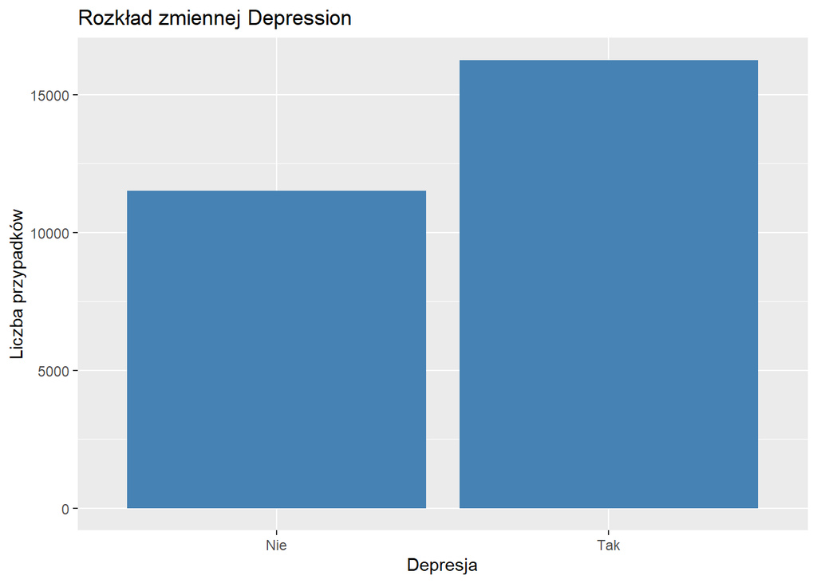

```r
library(ggplot2)
ggplot(data_model, aes(x = factor(Depression))) +  # Zamiana zmiennej na faktor
  geom_bar(fill = "steelblue") +
  scale_x_discrete(labels = c("0" = "Nie", "1" = "Tak")) +  # Opcjonalne etykiety dla klas
  labs(title = "Rozkład zmiennej Depression", x = "Depresja", y = "Liczba przypadków")
```

```r
# Liczba przypadków w każdej klasie
print(table(data_model$Depression))
```

```
##
##     0     1
## 11526 16262
```

```r
# Proporcje klas
data.frame(prop.table(table(data_model$Depression)))
```

| Var1 | Freq |
| --- | --- |
| 0 | 0.4147834 |
| 1 | 0.5852166 |

Proporcja 58,5% do 41,5% oznacza, że zbiór danych jest w miarę zrównoważony, ponieważ różnica między klasami zmiennej objaśnianej nie jest bardzo duża.

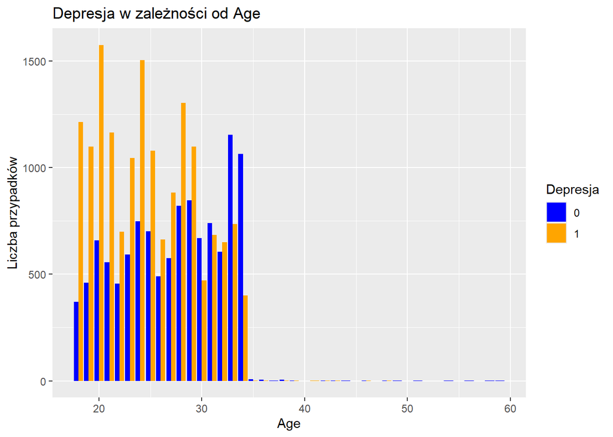

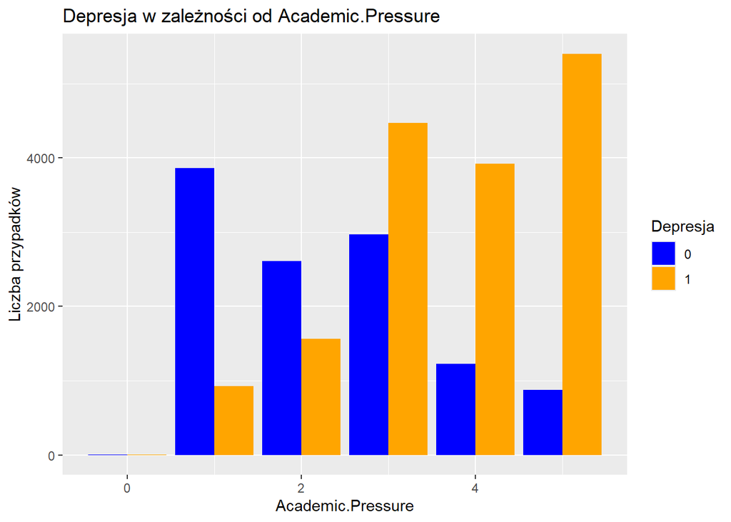

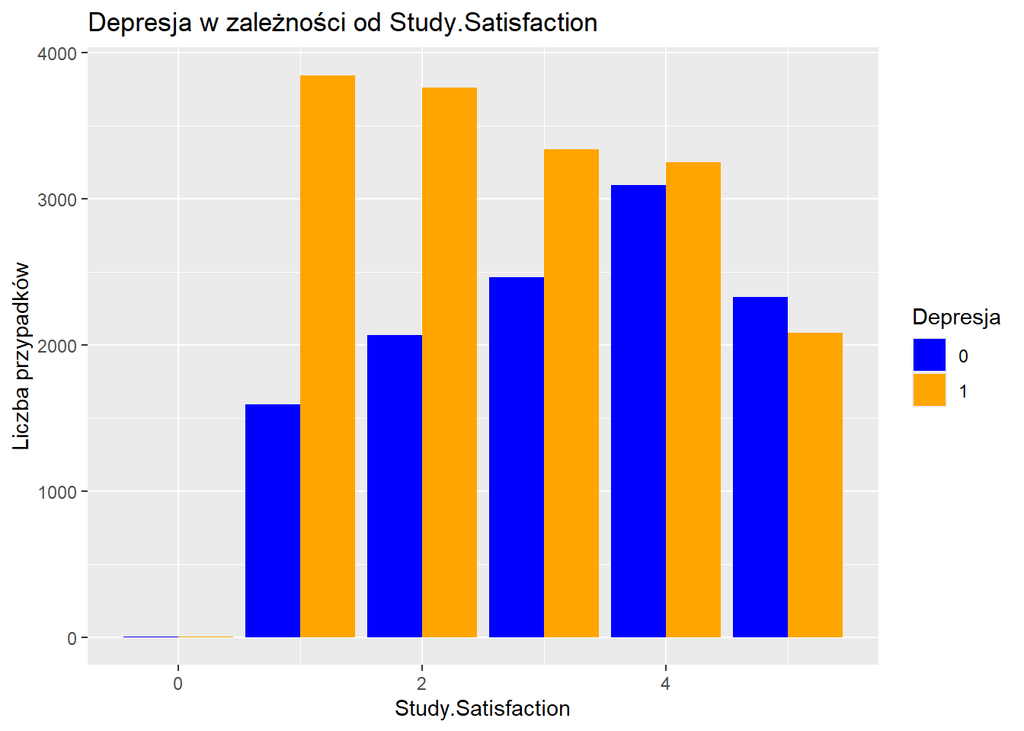

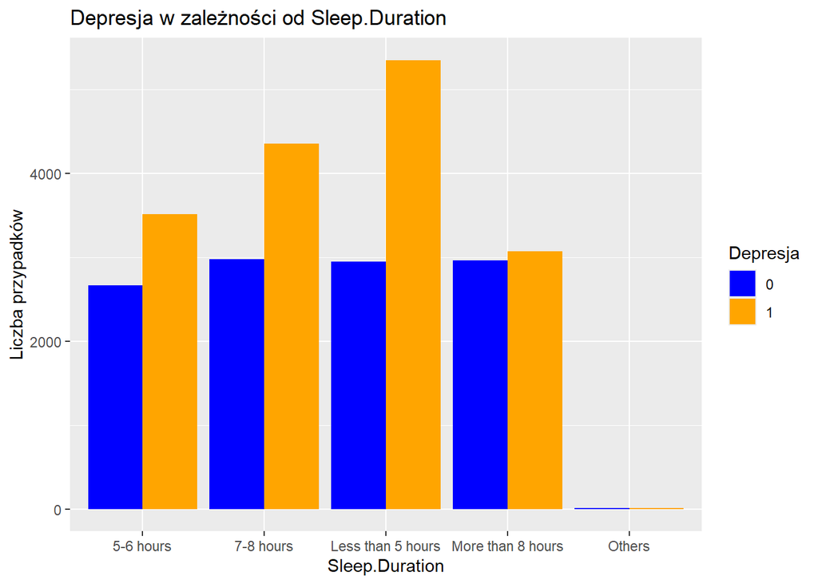

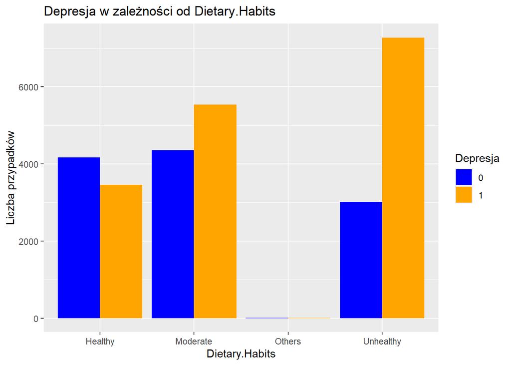

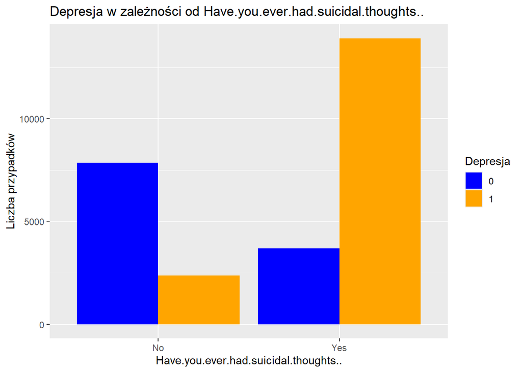

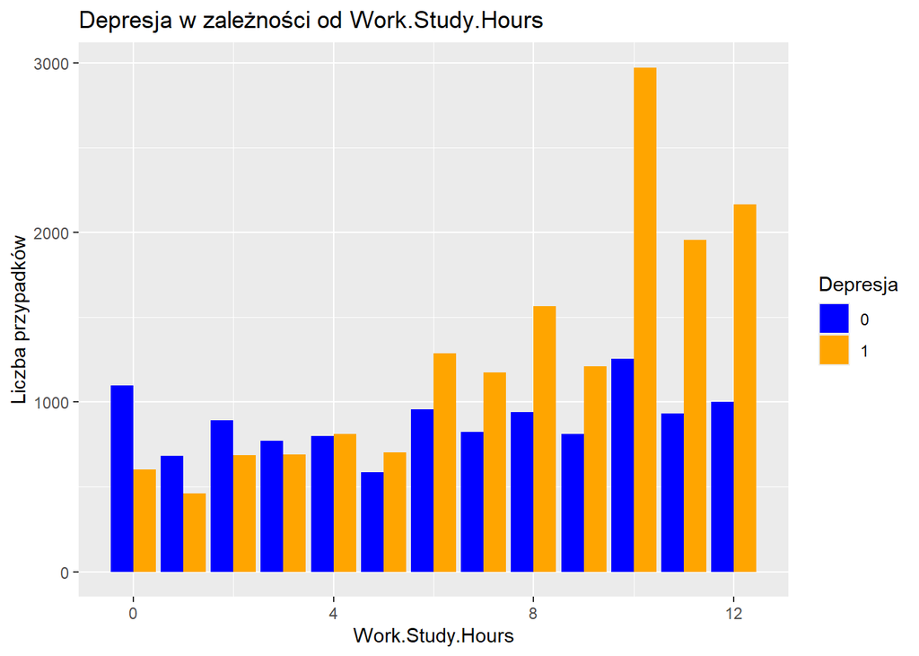

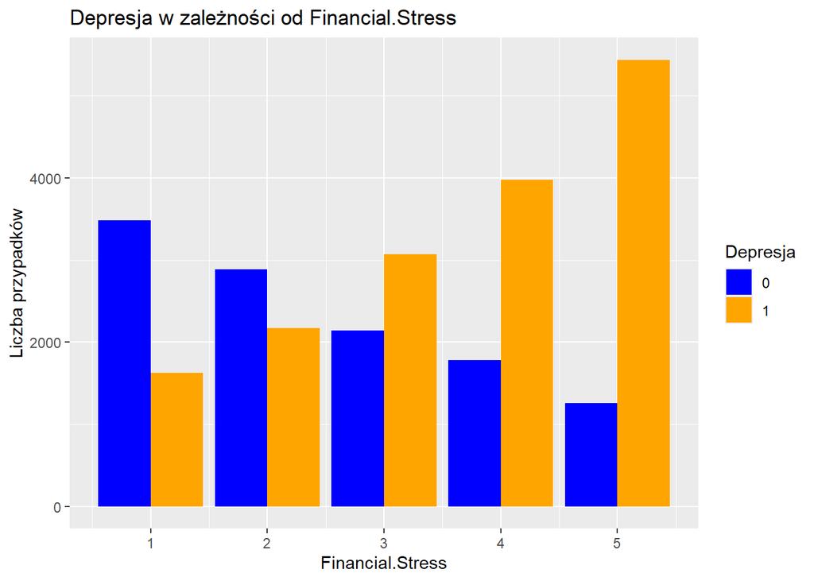

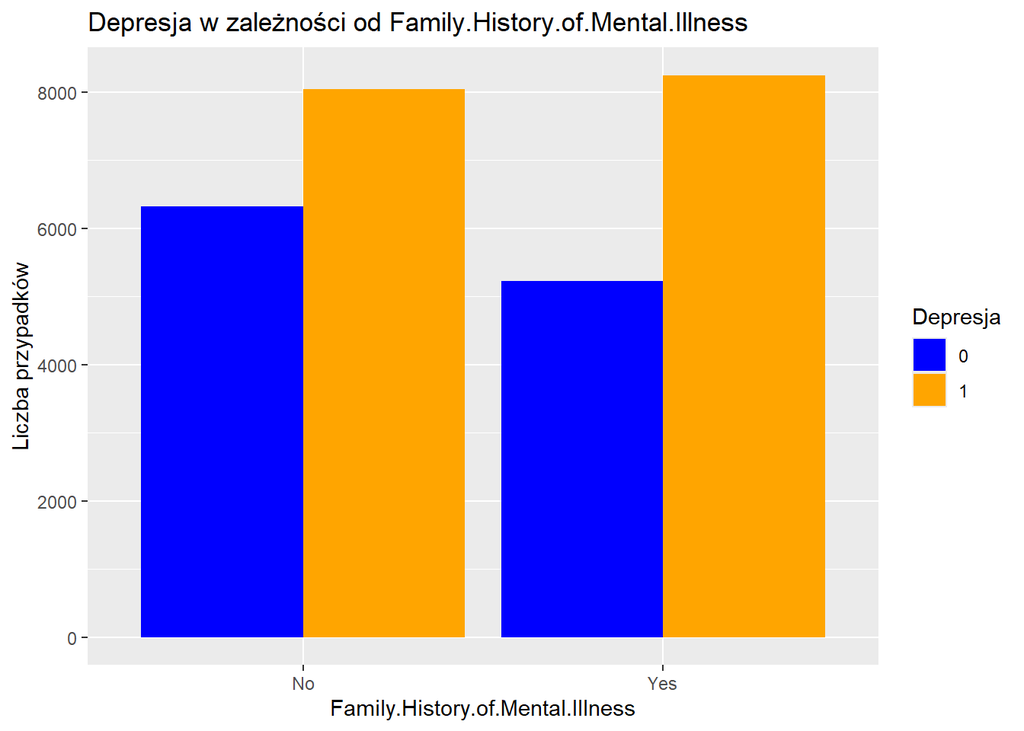

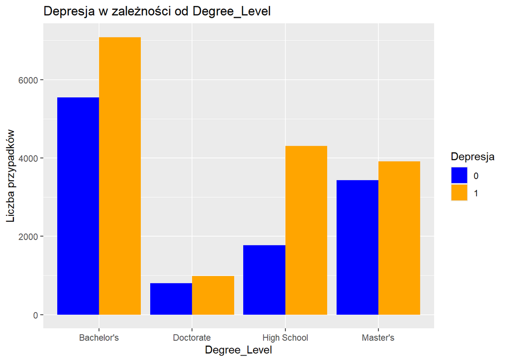

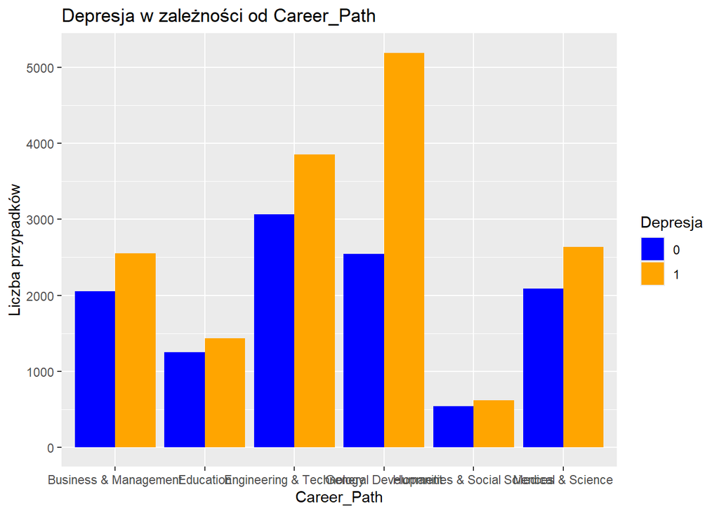

```r
create_depression_plot <- function(data, explanatory_vars, target_var = "Depression") {
  library(ggplot2)

  # Exclude specific variables from the plotting process
  excluded_vars <- c("Work.Pressure", "CGPA", "Job.Satisfaction")
  explanatory_vars <- setdiff(explanatory_vars, excluded_vars)

  # Iterate over each explanatory variable and create a plot
  for (var in explanatory_vars) {
    # Generate the plot
    p <- ggplot(data, aes_string(x = var, fill = paste0("factor(", target_var, ")"))) +
      geom_bar(position = "dodge") +
      labs(
        title = paste("Depresja w zależności od", var),
        x = var,
        y = "Liczba przypadków"
      ) +
      scale_fill_manual(values = c("0" = "blue", "1" = "orange"), name = "Depresja")

    # Print the plot
    print(p)
  }
}

explanatory_vars <- setdiff(names(data), c("id", "Depression", "City", "Gender", "Profession", "Degree", "Have you ever had suicidal thoughts ?", "Sleep Duration", "Dietary Habits", "Work Pressure", "CGPA", "Job Satisfaction"))

# Call the function
create_depression_plot(data, explanatory_vars)
```

# Podział na zbiór uczący i testowy

```r
library(caret)

# Ustawienie losowości
set.seed(123) # Dla reprodukowalności

# Podział danych: 70% uczący, 30% testowy
train_index <- createDataPartition(data_model$Depression, p = 0.7, list = FALSE)

# Tworzenie zbioru uczącego i testowego
train_data <- data_model[train_index, ]
test_data <- data_model[-train_index, ]

# Sprawdzenie rozmiarów zbiorów
nrow(train_data) # Liczba obserwacji w zbiorze uczącym
```

```
## [1] 19453
```

```r
nrow(test_data)  # Liczba obserwacji w zbiorze testowym
```

```
## [1] 8335
```

# Metdoy uczenia maszynowego

## Drzewa decyzyjne

Parametry do testowania:

- Reguła podziału (split):
- gini (indeks Giniego): Minimalizuje impurety w każdym podziale.
- information (entropia): Maksymalizuje zysk informacji przy każdym podziale.
- Minimalna liczba obserwacji w węźle końcowym (minbucket - określa minimalną liczbę obserwacji, jakie muszą być w każdym liściu.)
- Testowane wartości: 50, 500, 2000
- Minimalna liczba obserwacji do dalszego podziału (minsplit - lczba obserwacji wymagana w węźle, aby był podzielony)
- Testowane wartości: 50, 500, 2000
- Maksymalna głębokość drzewa (maxdepth - określa maksymalną liczbę poziomów drzewa)
- Testowane wartości: 2, 5, 8

```r
library(rpart)

library(caret)

# Listy parametrów do testowania
split_methods <- c("gini", "information")
minbucket_values <- c(50, 500, 2000)
minsplit_values <- c(50, 500, 2000)
maxdepth_values <- c(2, 5, 8)
# Inicjalizacja pustej ramki danych do przechowywania wyników
results <- data.frame(
  Split_Method = character(),
  MinBucket = integer(),
  MinSplit = integer(),
  MaxDepth = integer(),
  Train_Accuracy = numeric(),
  Test_Accuracy = numeric(),
  stringsAsFactors = FALSE
)

best_test_accuracy <- -Inf
best_model <- NULL
best_params <- NULL

# Iteracja przez wszystkie kombinacje parametrów
for (split_method in split_methods) {
  for (minbucket in minbucket_values) {
    for (minsplit in minsplit_values) {
      for (maxdepth in maxdepth_values) {

        # Tworzenie drzewa decyzyjnego
        tree <- rpart(Depression ~ ., data = train_data, method = "class",
                      parms = list(split = split_method),
                      control = rpart.control(minbucket = minbucket,
                                              minsplit = minsplit,
                                              maxdepth = maxdepth))

        # Predykcja dla zbioru treningowego
        pred_train <- predict(tree, train_data, type = "class")
        conf_matrix_train <- confusionMatrix(pred_train, as.factor(train_data$Depression), positive = "1")
        train_accuracy <- conf_matrix_train$overall['Accuracy']

        # Predykcja dla zbioru testowego
        pred_test <- predict(tree, test_data, type = "class")
        conf_matrix_test <- confusionMatrix(pred_test, as.factor(test_data$Depression), positive = "1")
        test_accuracy <- conf_matrix_test$overall['Accuracy']

        # Dodanie wyników do ramki danych
        results <- rbind(results, data.frame(
          Split_Method = split_method,
          MinBucket = minbucket,
          MinSplit = minsplit,
          MaxDepth = maxdepth,
          Train_Accuracy = train_accuracy,
          Test_Accuracy = test_accuracy
        ))

        if (test_accuracy > best_test_accuracy) {
          best_test_accuracy <- test_accuracy
          best_model <- tree
          best_params <- list(
            Split_Method = split_method,
            MinBucket = minbucket,
            MinSplit = minsplit,
            MaxDepth = maxdepth,
            Test_Accuracy = test_accuracy
          )
        }
      }
    }
  }
}
```

```r
# Wyświetlenie wyników
data.frame(results)
```

|  | Split_Method | MinBucket | MinSplit | MaxDepth | Train_Accuracy | Test_Accuracy |
| --- | --- | --- | --- | --- | --- | --- |
| Accuracy | gini | 50 | 50 | 2 | 0.7812677 | 0.7851230 |
| Accuracy1 | gini | 50 | 50 | 5 | 0.8219298 | 0.8219556 |
| Accuracy2 | gini | 50 | 50 | 8 | 0.8219298 | 0.8219556 |
| Accuracy3 | gini | 50 | 500 | 2 | 0.7812677 | 0.7851230 |
| Accuracy4 | gini | 50 | 500 | 5 | 0.8219298 | 0.8219556 |
| Accuracy5 | gini | 50 | 500 | 8 | 0.8219298 | 0.8219556 |
| Accuracy6 | gini | 50 | 2000 | 2 | 0.7812677 | 0.7851230 |
| Accuracy7 | gini | 50 | 2000 | 5 | 0.8055313 | 0.8067187 |
| Accuracy8 | gini | 50 | 2000 | 8 | 0.8055313 | 0.8067187 |
| Accuracy9 | gini | 500 | 50 | 2 | 0.7812677 | 0.7851230 |

[output cut: 44 more lines]

Żaden z powyższych modeli nie jest przeuczony. Aby lepiej zinterpretować hiperparametry pogrupowaliśmy uzyskane wyniki

```r
low_accuracy <- results[results$Test_Accuracy < 0.79, ]
medium_accuracy <- results[results$Test_Accuracy >= 0.79 & results$Test_Accuracy < 0.81, ]
high_accuracy <- results[results$Test_Accuracy >= 0.81, ]
```

Najlepsze wyniki:

```r
high_accuracy
```

|  | Split_Method | MinBucket | MinSplit | MaxDepth | Train_Accuracy | Test_Accuracy |
| --- | --- | --- | --- | --- | --- | --- |
| Accuracy1 | gini | 50 | 50 | 5 | 0.8219298 | 0.8219556 |
| Accuracy2 | gini | 50 | 50 | 8 | 0.8219298 | 0.8219556 |
| Accuracy4 | gini | 50 | 500 | 5 | 0.8219298 | 0.8219556 |
| Accuracy5 | gini | 50 | 500 | 8 | 0.8219298 | 0.8219556 |
| Accuracy10 | gini | 500 | 50 | 5 | 0.8219298 | 0.8219556 |
| Accuracy11 | gini | 500 | 50 | 8 | 0.8219298 | 0.8219556 |
| Accuracy13 | gini | 500 | 500 | 5 | 0.8219298 | 0.8219556 |
| Accuracy14 | gini | 500 | 500 | 8 | 0.8219298 | 0.8219556 |
| Accuracy28 | information | 50 | 50 | 5 | 0.8219298 | 0.8219556 |
| Accuracy29 | information | 50 | 50 | 8 | 0.8219298 | 0.8219556 |

[output cut: 6 more lines]

Najgorsze wyniki:

```r
low_accuracy
```

|  | Split_Method | MinBucket | MinSplit | MaxDepth | Train_Accuracy | Test_Accuracy |
| --- | --- | --- | --- | --- | --- | --- |
| Accuracy | gini | 50 | 50 | 2 | 0.7812677 | 0.785123 |
| Accuracy3 | gini | 50 | 500 | 2 | 0.7812677 | 0.785123 |
| Accuracy6 | gini | 50 | 2000 | 2 | 0.7812677 | 0.785123 |
| Accuracy9 | gini | 500 | 50 | 2 | 0.7812677 | 0.785123 |
| Accuracy12 | gini | 500 | 500 | 2 | 0.7812677 | 0.785123 |
| Accuracy15 | gini | 500 | 2000 | 2 | 0.7812677 | 0.785123 |
| Accuracy18 | gini | 2000 | 50 | 2 | 0.7812677 | 0.785123 |
| Accuracy19 | gini | 2000 | 50 | 5 | 0.7812677 | 0.785123 |
| Accuracy20 | gini | 2000 | 50 | 8 | 0.7812677 | 0.785123 |
| Accuracy21 | gini | 2000 | 500 | 2 | 0.7812677 | 0.785123 |

[output cut: 20 more lines]

Najlepsze wyniki uzyskano dla modeli, w których wartość hiperparametru MinBucket i MinSplit nie wynosi 2000, ponieważ ustawienie bardzo dużych wartości powoduje, że drzewo decyzyjne staje się zbyt proste, co skutkuje niedotrenowaniem. Drzewo nie jest w stanie podzielić danych na wystarczająco małe grupy, aby uchwycić ważne wzorce oraz ignoruje istotne niuanse w danych. Dodatkowo największa głębokość drzewa ustawiona na 2 okazała się niewystarczająca.  
Do dalszego badania wybraliśmy model o następujących parametrach:

```r
data.frame(best_params)
```

|  | Split_Method | MinBucket | MinSplit | MaxDepth | Test_Accuracy |
| --- | --- | --- | --- | --- | --- |
| Accuracy | gini | 50 | 50 | 5 | 0.8219556 |

Tak wygląda jego wykres:

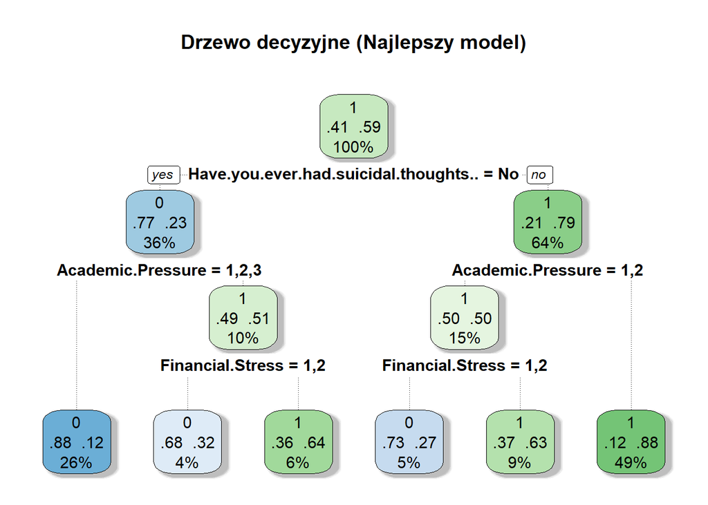

```r
library(rpart.plot)
rpart.plot(best_model,
           main = "Drzewo decyzyjne (Najlepszy model)",
           type = 2, # Typ wizualizacji (prostokątne liście)
           extra = 104, # Wyświetla klasyfikację i prawdopodobieństwo
           box.palette = "auto", # Automatyczna kolorystyka
           branch.lty = 3, # Styl gałęzi (linia przerywana)
           shadow.col = "gray") # Cień dla efektu 3D
```

### Bagging

W kontekście drzew decyzyjnych, parametr nbagg odnosi się do liczby drzew, które zostaną wytrenowane w ramach baggingu. Przetestowane wartości parametru to: 10, 50 i 100. Pozostałe parametry zostały takie same jak w wcześniej wybranym drzewie

```r
        library(ipred)
        library(caret)

        # Wartości nbagg do przetestowania
        nbagg_values <- c(10, 50, 100)

        # Ramka danych do przechowywania wyników
        results2 <- data.frame(
          nbagg = integer(),
          Train_Accuracy = numeric(),
          Test_Accuracy = numeric(),
          stringsAsFactors = FALSE
        )

        # Iteracja przez różne wartości nbagg
        for (nbagg in nbagg_values) {
          set.seed(123)  # Reprodukowalność

          # Bagging z określoną wartością nbagg
          bagged_model <- bagging(Depression ~ ., data = train_data,
                                  nbagg = nbagg,  # Liczba bootstrapowanych drzew
                                  coob = TRUE,    # Ocena błędu OOB
                                  control = rpart.control(
                                    minbucket = best_params$MinBucket,
                                    minsplit = best_params$MinSplit,
                                    maxdepth = best_params$MaxDepth
                                  ))

          # Predykcja na zbiorze treningowym
          pred_train <- predict(bagged_model, train_data, type = "class")
          pred_train <- factor(pred_train, levels = levels(train_data$Depression))  # Synchronizacja poziomów
          conf_matrix_train <- confusionMatrix(pred_train, train_data$Depression, positive = "1")
          train_accuracy <- conf_matrix_train$overall['Accuracy']

          # Predykcja na zbiorze testowym
          pred_test <- predict(bagged_model, test_data, type = "class")
          pred_test <- factor(pred_test, levels = levels(test_data$Depression))  # Synchronizacja poziomów
          conf_matrix_test <- confusionMatrix(pred_test, test_data$Depression, positive = "1")
          test_accuracy <- conf_matrix_test$overall['Accuracy']

          # Dodanie wyników do ramki danych
          results2 <- rbind(results2, data.frame(
            nbagg = nbagg,
            Train_Accuracy = train_accuracy,
            Test_Accuracy = test_accuracy
          ))
        }
```

```r
# Wyświetlenie wyników
        data.frame(results2)
```

|  | nbagg | Train_Accuracy | Test_Accuracy |
| --- | --- | --- | --- |
| Accuracy | 10 | 0.8219298 | 0.8219556 |
| Accuracy1 | 50 | 0.8219298 | 0.8219556 |
| Accuracy2 | 100 | 0.8219298 | 0.8219556 |

Bagging nie poprawił wyników modelu. Możliwe, że jest to spowodowane dobrym zbalansowaniem danych lub zbyt restrykcyjnymi hiperparametrami.

## Regresja logistyczna

Model zwraca prawdopodobieństwo przynależności do danej klasy (np. prawdopodobieństwo przynależności do “1” wynosi 65%). Jeśli prawdopodobieństwo przewidywane jest większe niż określony próg (0.5), punkt zostaje przypisany do klasy “1”; w przeciwnym razie do klasy “0”. Zastosowaliśmy przekształcenie one-hot encoding - ważne aby usunąć jedna z kolumn, aby uniknąć współliniowości. Tak prezentuje się kilka rekordów ze zbioru treningowewgo:

```r
library(caret)
library(fastDummies)

categorical_columns <- names(train_data)[sapply(train_data, is.factor)]
train_data_encoded <- dummy_cols(
  train_data,
  select_columns = categorical_columns,
  remove_first_dummy = TRUE,  # Usunięcie pierwszej kolumny, aby uniknąć współliniowości
  remove_selected_columns = TRUE # Usunięcie oryginalnych kolumn
)

# One-hot encoding dla zbioru testowego
test_data_encoded <- dummy_cols(
  test_data,
  select_columns = categorical_columns,
  remove_first_dummy = TRUE,  # Usunięcie pierwszej kolumny, aby uniknąć współliniowości
  remove_selected_columns = TRUE # Usunięcie oryginalnych kolumn
)
head(train_data_encoded)
```

|  | Age | CGPA | Work.Study.Hours | Gender_Male | Academic.Pressure_1 | Academic.Pressure_2 | Academic.Pressure_3 | Academic.Pressure_4 | Academic.Pressure_5 | Study.Satisfaction_1 | Study.Satisfaction_2 | Study.Satisfaction_3 | Study.Satisfaction_4 | Study.Satisfaction_5 | Sleep.Duration_2 | Sleep.Duration_3 | Sleep.Duration_4 | Dietary.Habits_2 | Dietary.Habits_3 | Have.you.ever.had.suicidal.thoughts.._Yes | Financial.Stress_2 | Financial.Stress_3 | Financial.Stress_4 | Financial.Stress_5 | Family.History.of.Mental.Illness_Yes | Depression_1 | Degree_Level_1 | Degree_Level_2 | Degree_Level_3 | … |
| --- | --- | --- | --- | --- | --- | --- | --- | --- | --- | --- | --- | --- | --- | --- | --- | --- | --- | --- | --- | --- | --- | --- | --- | --- | --- | --- | --- | --- | --- | --- |
| 1 | 33 | 8.97 | 3 | 1 | 0 | 0 | 0 | 0 | 1 | 0 | 1 | 0 | 0 | 0 | 1 | 0 | 0 | 0 | 0 | 1 | 0 | 0 | 0 | 0 | 0 | 1 | 1 | 0 | 0 | … |
| 2 | 24 | 5.90 | 3 | 0 | 0 | 1 | 0 | 0 | 0 | 0 | 0 | 0 | 0 | 1 | 1 | 0 | 0 | 1 | 0 | 0 | 1 | 0 | 0 | 0 | 1 | 0 | 1 | 0 | 0 | … |
| 3 | 31 | 7.03 | 9 | 1 | 0 | 0 | 1 | 0 | 0 | 0 | 0 | 0 | 0 | 1 | 0 | 0 | 0 | 0 | 0 | 0 | 0 | 0 | 0 | 0 | 1 | 0 | 1 | 0 | 0 | … |
| 4 | 28 | 5.59 | 4 | 0 | 0 | 0 | 1 | 0 | 0 | 0 | 1 | 0 | 0 | 0 | 0 | 1 | 0 | 1 | 0 | 1 | 0 | 0 | 0 | 1 | 1 | 1 | 1 | 0 | 0 | … |
| 5 | 25 | 8.13 | 1 | 0 | 0 | 0 | 0 | 1 | 0 | 0 | 0 | 1 | 0 | 0 | 1 | 0 | 0 | 1 | 0 | 1 | 0 | 0 | 0 | 0 | 0 | 0 | 0 | 1 | 0 | … |
| 6 | 30 | 9.54 | 1 | 1 | 0 | 0 | 1 | 0 | 0 | 0 | 0 | 0 | 1 | 0 | 0 | 1 | 0 | 0 | 0 | 0 | 1 | 0 | 0 | 0 | 0 | 0 | 1 | 0 | 0 | … |

Następnie tworzymy model, kolejno usuwając z niego zmienne nieistotne na poziomie 0.05, zaczynając od tej z najwiękaszą wartością p-value. Ostateczny model ma następujące parametry:

```r
# Sprawdzenie wyników
remove_high_p_variables <- function(model, data, p_threshold = 0.1) {
  while (TRUE) {
    # Podsumowanie modelu
    summary_model <- summary(model)

    # Wyciąganie wartości p dla zmiennych (bez interceptu)
    p_values <- summary_model$coefficients[-1, 4]  # Pomijamy intercept

    # Znalezienie zmiennej z najwyższym p-value
    max_p_value <- max(p_values, na.rm = TRUE)

    # Jeśli wszystkie p-value są poniżej progu, kończymy pętlę
    if (max_p_value < p_threshold) break

    # Zidentyfikowanie nazwy zmiennej do usunięcia
    variable_to_remove <- names(p_values)[which.max(p_values)]

    # Wyświetlenie informacji o usuwanej zmiennej
    cat("Usuwanie zmiennej:", variable_to_remove, "z p-value:", max_p_value, "\n")

    # Aktualizacja formuły modelu
    formula <- as.formula(paste("Depression_1 ~ . -", variable_to_remove))
    model <- update(model, formula, data = data)
  }

  # Zwracamy ostateczny model
  return(model)
}
model_logistic <- glm(Depression_1 ~ ., data = train_data_encoded, family = "binomial")

# Uruchomienie funkcji
final_model <- remove_high_p_variables(model_logistic, train_data_encoded , p_threshold = 0.05)
```

```
## Usuwanie zmiennej: Gender_Male z p-value: 0.924869
## Usuwanie zmiennej: Career_Path_1 z p-value: 0.5816016
## Usuwanie zmiennej: Career_Path_3 z p-value: 0.6400889
## Usuwanie zmiennej: Degree_Level_3 z p-value: 0.5314936
## Usuwanie zmiennej: Career_Path_4 z p-value: 0.1581601
## Usuwanie zmiennej: Degree_Level_1 z p-value: 0.09314587
## Usuwanie zmiennej: Degree_Level_2 z p-value: 0.2556946
```

Usunięto kolejno zmienne opisujące:

- Płeć
- Drogę kariery (Czy Career_Path należy do podkategorii nr 1 - Engineering & Technology)
- Drogę kariery (Czy Career_Path należy do podkategorii nr 3 - Education)
- Poziom naukowy (Czy Degree_Level należy do podkategorii nr 3 - Doctorate)
- Drogę kariery (Czy Career_Path należy do podkategorii nr 4 - Business & Management)
- Poziom naukowy (Czy Degree_Level należy do podkategorii nr 1 - Master’s)
- Poziom naukowy (Czy Degree_Level należy do podkategorii nr 2 - Bachelor’s)

W skróciie usunięto wpływ całej zmiennej Degree_Level, Gender oraz części zmiennej Career_Path.

Tak wyglądają współczynniki istotnych zmiennych:

```r
# Podsumowanie ostatecznego modelu
library(knitr)
library(kableExtra)

# Pobranie podsumowania modelu
model_summary <- summary(final_model)

# Sprawdzenie, czy model to regresja logistyczna (glm z binomial)
if ("z value" %in% colnames(model_summary$coefficients)) {
  statistic_column <- "z value"
  pvalue_column <- "Pr(>|z|)"
} else {
  statistic_column <- "t value"
  pvalue_column <- "Pr(>|t|)"
}

# Ekstrakcja istotnych informacji do tabeli z obsługą NA
model_table <- data.frame(
  Term = rownames(model_summary$coefficients),
  Estimate = model_summary$coefficients[, "Estimate"],
  StdError = model_summary$coefficients[, "Std. Error"],
  Statistic = model_summary$coefficients[, statistic_column],
  PValue = model_summary$coefficients[, pvalue_column]
)

# Usunięcie wierszy z wartościami NA
model_table <- model_table[complete.cases(model_table), ]

# Dodanie kolumny z gwiazdkami dla poziomu istotności
model_table$Significance <- cut(
  model_table$PValue,
  breaks = c(-Inf, 0.001, 0.01, 0.05, 0.1, Inf),
  labels = c("*", "*", "", ".", ""),
  right = FALSE
)

# Formatowanie tabeli
kable(model_table, caption = "Podsumowanie modelu regresji") %>%
  kable_styling(bootstrap_options = c("striped", "hover", "condensed"),
                full_width = FALSE,
                position = "left") %>%
  column_spec(1, bold = TRUE) %>%
  add_header_above(c("Parametry Modelu" = 7))
```

Podsumowanie modelu regresji

Parametry Modelu